# INFO 201L Final Project – Join Data

Author

Hannah Park & Zoey Ha

Published

March 10, 2026

```r
library("dplyr")
```

## Part I: Find the Data

### First

```r
sleep_health_lifestyle_df <- read.csv("Sleep_health_and_lifestyle_dataset.csv")

glimpse(sleep_health_lifestyle_df)
```

```
Rows: 374
Columns: 13
$ Person.ID               <int> 1, 2, 3, 4, 5, 6, 7, 8, 9, 10, 11, 12, 13, 14,…
$ Gender                  <chr> "Male", "Male", "Male", "Male", "Male", "Male"…
$ Age                     <int> 27, 28, 28, 28, 28, 28, 29, 29, 29, 29, 29, 29…
$ Occupation              <chr> "Software Engineer", "Doctor", "Doctor", "Sale…
$ Sleep.Duration          <dbl> 6.1, 6.2, 6.2, 5.9, 5.9, 5.9, 6.3, 7.8, 7.8, 7…
$ Quality.of.Sleep        <int> 6, 6, 6, 4, 4, 4, 6, 7, 7, 7, 6, 7, 6, 6, 6, 6…
$ Physical.Activity.Level <int> 42, 60, 60, 30, 30, 30, 40, 75, 75, 75, 30, 75…
$ Stress.Level            <int> 6, 8, 8, 8, 8, 8, 7, 6, 6, 6, 8, 6, 8, 8, 8, 8…
$ BMI.Category            <chr> "Overweight", "Normal", "Normal", "Obese", "Ob…
$ Blood.Pressure          <chr> "126/83", "125/80", "125/80", "140/90", "140/9…
$ Heart.Rate              <int> 77, 75, 75, 85, 85, 85, 82, 70, 70, 70, 70, 70…
$ Daily.Steps             <int> 4200, 10000, 10000, 3000, 3000, 3000, 3500, 80…
$ Sleep.Disorder          <chr> "None", "None", "None", "Sleep Apnea", "Sleep …
```

This dataset was created by Ben Cutting. It includes individuals’ age, sleep duration, stress level, and physical activity records. The dataset is used to explore the relationship between mental health and sleep. This dataset is reliable because it was funded by the University of Oxford.

This dataset have total 13 columns and 374 rows.

### Second

```r
stress_detection_df <- read.csv("SaYoPillow.csv")

glimpse(stress_detection_df)
```

```
Rows: 630
Columns: 9
$ sr   <dbl> 93.800, 91.640, 60.000, 85.760, 48.120, 56.880, 47.000, 50.000, 4…
$ rr   <dbl> 25.680, 25.104, 20.000, 23.536, 17.248, 19.376, 16.800, 18.000, 1…
$ t    <dbl> 91.840, 91.552, 96.000, 90.768, 97.872, 95.376, 97.200, 99.000, 9…
$ lm   <dbl> 16.600, 15.880, 10.000, 13.920, 6.496, 9.376, 5.600, 8.000, 4.224…
$ bo   <dbl> 89.840, 89.552, 95.000, 88.768, 96.248, 94.064, 95.800, 97.000, 9…
$ rem  <dbl> 99.60, 98.88, 85.00, 96.92, 72.48, 83.44, 68.00, 80.00, 61.12, 82…
$ sr.1 <dbl> 1.840, 1.552, 7.000, 0.768, 8.248, 6.376, 7.800, 9.000, 7.112, 6.…
$ hr   <dbl> 74.20, 72.76, 60.00, 68.84, 53.12, 58.44, 52.00, 55.00, 50.28, 57…
$ sl   <int> 3, 3, 1, 3, 0, 1, 0, 0, 0, 1, 2, 1, 0, 4, 3, 1, 1, 3, 3, 2, 2, 2,…
```

This dataset was created by researchers L. Rachakonda and collaborators as part of the SaYoPillow research project. It contains physiological and sleep related measurements such as respiration rate, body temperature, sleep duration, heart rate, and stress level. It designed to analyze the relationship between sleeping habits and stress. This dataset is reliable because it is based on a comprehensive literature review and was published in peer-reviewed IEEE journals and conferences.

This dataset have total 9 columns and 630 rows.

### Join

Three columns, sleep duration, hearth rate, stress level, overlap between the two datasets. We selected these three columns and will do a full join to analyze the relationship between sleep duration and stress level.

Since the column names are different, we used rename(). Additionally, the data types differed between the datasets (integer and double), so we will round the values and converted them to integer type.

We checked data set and we did not find any other unexpected values.

## Part II: Data Join

### Select Columns (Sleep Duration, Heart Rate, Stress Level)

```r
sleep_health_lifestyle_df <- sleep_health_lifestyle_df |>
  select(Sleep.Duration, Heart.Rate, Stress.Level)

stress_detection_df <- stress_detection_df |>
  select(sr.1, hr, sl)

glimpse(sleep_health_lifestyle_df)
```

```
Rows: 374
Columns: 3
$ Sleep.Duration <dbl> 6.1, 6.2, 6.2, 5.9, 5.9, 5.9, 6.3, 7.8, 7.8, 7.8, 6.1, …
$ Heart.Rate     <int> 77, 75, 75, 85, 85, 85, 82, 70, 70, 70, 70, 70, 70, 70,…
$ Stress.Level   <int> 6, 8, 8, 8, 8, 8, 7, 6, 6, 6, 8, 6, 8, 8, 8, 8, 7, 8, 7…
```

```r
glimpse(stress_detection_df)
```

```
Rows: 630
Columns: 3
$ sr.1 <dbl> 1.840, 1.552, 7.000, 0.768, 8.248, 6.376, 7.800, 9.000, 7.112, 6.…
$ hr   <dbl> 74.20, 72.76, 60.00, 68.84, 53.12, 58.44, 52.00, 55.00, 50.28, 57…
$ sl   <int> 3, 3, 1, 3, 0, 1, 0, 0, 0, 1, 2, 1, 0, 4, 3, 1, 1, 3, 3, 2, 2, 2,…
```

### Change Column Name

```r
sleep_health_lifestyle_df <- sleep_health_lifestyle_df |>
  rename(`Sleep Duration` = Sleep.Duration,
         `Heart Rate` = Heart.Rate,
         `Stress Level` = Stress.Level)

glimpse(sleep_health_lifestyle_df)
```

```
Rows: 374
Columns: 3
$ `Sleep Duration` <dbl> 6.1, 6.2, 6.2, 5.9, 5.9, 5.9, 6.3, 7.8, 7.8, 7.8, 6.1…
$ `Heart Rate`     <int> 77, 75, 75, 85, 85, 85, 82, 70, 70, 70, 70, 70, 70, 7…
$ `Stress Level`   <int> 6, 8, 8, 8, 8, 8, 7, 6, 6, 6, 8, 6, 8, 8, 8, 8, 7, 8,…
```

```r
stress_detection_df <- stress_detection_df |>
  rename(`Sleep Duration` = sr.1,
         `Heart Rate` = hr,
         `Stress Level` = sl)

glimpse(stress_detection_df)
```

```
Rows: 630
Columns: 3
$ `Sleep Duration` <dbl> 1.840, 1.552, 7.000, 0.768, 8.248, 6.376, 7.800, 9.00…
$ `Heart Rate`     <dbl> 74.20, 72.76, 60.00, 68.84, 53.12, 58.44, 52.00, 55.0…
$ `Stress Level`   <int> 3, 3, 1, 3, 0, 1, 0, 0, 0, 1, 2, 1, 0, 4, 3, 1, 1, 3,…
```

### Round and Change Type (double -> integer)

```r
sleep_health_lifestyle_df <- sleep_health_lifestyle_df |>
  mutate(
    `Sleep Duration` = as.integer(round(`Sleep Duration`))
  )

glimpse(sleep_health_lifestyle_df)
```

```
Rows: 374
Columns: 3
$ `Sleep Duration` <int> 6, 6, 6, 6, 6, 6, 6, 8, 8, 8, 6, 8, 6, 6, 6, 6, 6, 6,…
$ `Heart Rate`     <int> 77, 75, 75, 85, 85, 85, 82, 70, 70, 70, 70, 70, 70, 7…
$ `Stress Level`   <int> 6, 8, 8, 8, 8, 8, 7, 6, 6, 6, 8, 6, 8, 8, 8, 8, 7, 8,…
```

```r
stress_detection_df <- stress_detection_df |>
  mutate(
    `Sleep Duration` = as.integer(round(`Sleep Duration`)),
    `Heart Rate` = as.integer(round(`Heart Rate`))
  )

glimpse(stress_detection_df)
```

```
Rows: 630
Columns: 3
$ `Sleep Duration` <int> 2, 2, 7, 1, 8, 6, 8, 9, 7, 6, 4, 7, 8, 0, 1, 5, 6, 1,…
$ `Heart Rate`     <int> 74, 73, 60, 69, 53, 58, 52, 55, 50, 58, 63, 60, 54, 7…
$ `Stress Level`   <int> 3, 3, 1, 3, 0, 1, 0, 0, 0, 1, 2, 1, 0, 4, 3, 1, 1, 3,…
```

### Multiply the stress level column in stress_detection_df by 2

```r
stress_detection_df <- stress_detection_df |>
  mutate(`Stress Level` = as.integer(`Stress Level`) * 2)

glimpse(stress_detection_df)
```

```
Rows: 630
Columns: 3
$ `Sleep Duration` <int> 2, 2, 7, 1, 8, 6, 8, 9, 7, 6, 4, 7, 8, 0, 1, 5, 6, 1,…
$ `Heart Rate`     <int> 74, 73, 60, 69, 53, 58, 52, 55, 50, 58, 63, 60, 54, 7…
$ `Stress Level`   <dbl> 6, 6, 2, 6, 0, 2, 0, 0, 0, 2, 4, 2, 0, 8, 6, 2, 2, 6,…
```

### Join Two Data Set

```r
joined_df <- sleep_health_lifestyle_df |>
  full_join(stress_detection_df, by = c("Sleep Duration", "Heart Rate", "Stress Level"))

glimpse(joined_df)
```

```
Rows: 1,004
Columns: 3
$ `Sleep Duration` <int> 6, 6, 6, 6, 6, 6, 6, 8, 8, 8, 6, 8, 6, 6, 6, 6, 6, 6,…
$ `Heart Rate`     <int> 77, 75, 75, 85, 85, 85, 82, 70, 70, 70, 70, 70, 70, 7…
$ `Stress Level`   <dbl> 6, 8, 8, 8, 8, 8, 7, 6, 6, 6, 8, 6, 8, 8, 8, 8, 7, 8,…
```

### What we did

- Select columns (Sleep Duration, Heart Rate, Stress Level)
- Change column names
- Round and change type (double -> integer)
- Multiply the stress level column in stress_detection_df by 2
- Join Two Data Set

## Part III: Data Documentation

### Sleep Health and Lifestyle Dataset

The Sleep Health and Lifestyle dataset is published on Mendeley Data under the title “Health and Sleep relation 2024.” It was contributed by Ben Cutting and published in March 2025 (DOI: 10.17632/46j8wrc7p7.1). The project was funded by the University of Oxford.

A separate formal codebook document was not provided; however, the dataset description explains that the data includes individual sleep habits, health metrics, and lifestyle factors. The CSV file contains 13 variables including Sleep Duration (hours), Quality of Sleep (scale 1–10), Stress Level (scale 1–10), Heart Rate (beats per minute), Physical Activity Level (minutes per day), and demographic features such as age and gender. These descriptions provide sufficient context to interpret the variables for analysis.

### SaYoPillow Stress Detection Dataset

The SaYoPillow dataset is based on research conducted by L. Rachakonda and collaborators, published in IEEE Transactions on Consumer Electronics (2021) and IEEE iSES (2018). The dataset models the relationship between physiological signals and stress levels during sleep.

The dataset includes variables such as snoring range, respiration rate, body temperature, limb movement rate, blood oxygen levels, eye movement, sleep duration (hours), heart rate, and stress level. Stress is categorized on a scale from 0 to 4, where 0 represents low/normal stress and 4 represents high stress.

According to the dataset description, the values were generated based on a comprehensive literature review and not collected from human subjects directly. While the structure is grounded in peer-reviewed research, the dataset represents modeled physiological patterns rather than raw participant measurements.

## Part IV: Combined Data Wrangling

### Action 1: Removed Missing Values

We filtered out rows containing missing values in Sleep Duration, Heart Rate, or Stress Level to ensure our analysis is based only on complete observations.

```r
joined_df <- joined_df |>
  filter(!is.na(`Sleep Duration`),
         !is.na(`Heart Rate`),
         !is.na(`Stress Level`))

nrow(joined_df)
```

```
[1] 1004
```

### Action 2: Created High Stress Indicator

We created a new logical variable called High_Stress. This variable is TRUE when stress level is greater than 7 and FALSE otherwise. This allows us to group observations into high-stress and lower-stress categories for comparison.

```r
joined_df <- joined_df |>
  mutate(
    High_Stress = `Stress Level` > 7
  )

glimpse(joined_df)
```

```
Rows: 1,004
Columns: 4
$ `Sleep Duration` <int> 6, 6, 6, 6, 6, 6, 6, 8, 8, 8, 6, 8, 6, 6, 6, 6, 6, 6,…
$ `Heart Rate`     <int> 77, 75, 75, 85, 85, 85, 82, 70, 70, 70, 70, 70, 70, 7…
$ `Stress Level`   <dbl> 6, 8, 8, 8, 8, 8, 7, 6, 6, 6, 8, 6, 8, 8, 8, 8, 7, 8,…
$ High_Stress      <lgl> FALSE, TRUE, TRUE, TRUE, TRUE, TRUE, FALSE, FALSE, FA…
```

### Action 3: Summary Statistics by Stress Category

```r
stress_summary <- joined_df |>
  group_by(High_Stress) |>
  summarize(
    avg_sleep = mean(`Sleep Duration`, na.rm = TRUE),
    avg_heart_rate = mean(`Heart Rate`, na.rm = TRUE),
    count = n()
  )

stress_summary
```

```
# A tibble: 2 × 4
  High_Stress avg_sleep avg_heart_rate count
  <lgl>           <dbl>          <dbl> <int>
1 FALSE            5.63           63.9   808
2 TRUE             2.14           77.9   196
```

### Action 4: Visual Exploration

We created a scatterplot to explore the relationship between sleep duration and stress level. This visualization allows us to observe potential trends or patterns between sleep habits and stress intensity.

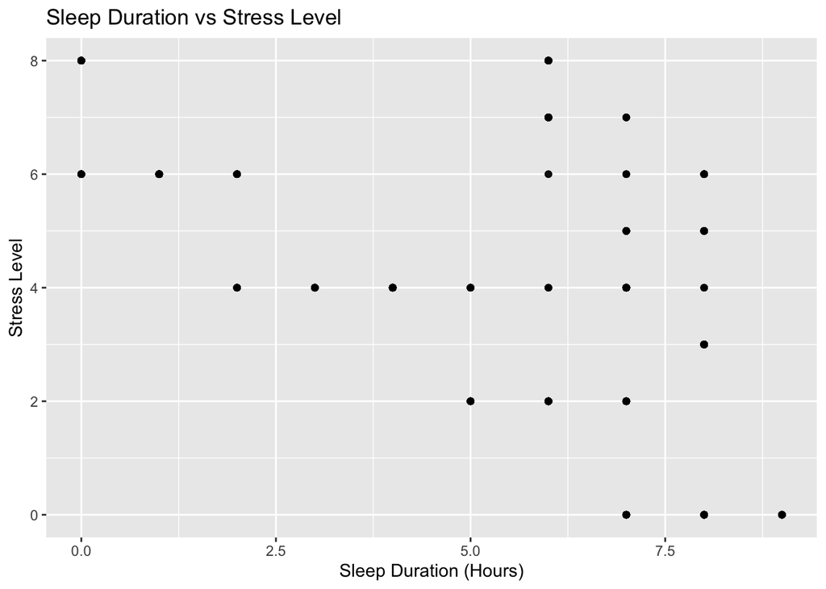

```r
library(ggplot2)

ggplot(joined_df, aes(x = `Sleep Duration`, y = `Stress Level`)) +
  geom_point(alpha = 0.5) +
  labs(title = "Sleep Duration vs Stress Level",
       x = "Sleep Duration (Hours)",
       y = "Stress Level")
```

## Section V: Group Information

### Group BB 8

Our group is mainly interested in exploring the relationship and potentially finding correlation between sleep patterns and stress levels, using physiological and lifestyle data. We are enrolled in the Lab Section BB with our Teaching Assistant, Sophia Dai.

### Hannah Park

Hannah Park (The Information School, University of Washington; hpark36@uw.edu) is interested in understanding how sleep habits influence stress and overall well-being. She is interested in data analysis and exploring how informatics can be applied to health and lifestyle research.

### Zoey Ha

Zoey Ha (Intended Informatics, University of Washington; zoeyha@uw.edu) is interested in examining how stress and physiological patterns interact with sleep behavior. She is interested in human-centered data analysis and applying informatics to health-related problem solving.

### Coding Notes

The majority of data cleaning, joining, and visualization steps were completed using tools introduced in class, including dplyr, tidyverse, group_by(), summarize(), mutate(), and ggplot2. We referenced lecture materials and previous lab exercises to guide our application.

Since the two datasets had different column names, we used the rename() function to standardize the column names before joining them. Additionally, the data types of the join columns were different (double vs. integer), so we used as.integer() to convert the values to the same type. To learn how to use as.integer(), we referred to the following resource: https://www.geeksforgeeks.org/r-language/convert-a-character-object-to-integer-in-r-programming-as-integer-function/